# 英超进球数探索分析

王思雨

2017年11月19日

## 一. 数据说明

$~~~~~~~$首先导入数据，然后使用 str，sumamry 命令可以大致了解到数据包含166个样本，34个变量。 可以做出下表更加详细的列出变量信息。

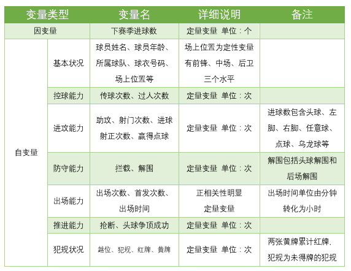

英超球员统计变量表

## 二. 解决方案与解决思路

$~~~~~~~$ **1.删除分类变量。**通过*summary*和*str*函数，可以发现该数据共有166行、34列，其中有3个分类变量，其中球员在场上的号码虽然是数值变量，但球员进球数是个人喜好，明显与球员号码无关，其实也应是字符型变量。因此我们得到了四个分类变量分别是球员姓名、球员所属球队、球员在比赛中的位置以及号码。很明显，球员下一季的进球数，与球员姓名和号码无直接关系。因为讨论的是球员在场上表现对球员下赛季进球数的影响，所以球员所属球队并不属于场上表现对本次的讨论并无关系。球员位置虽然在理论上影响球员的进球数，但是鉴于球员场上位置间接影响场上表现，例如后卫的防守能力强，所以拦截数和抢断数量多，所以场上位置可以通过其他场上表现变量反映，可以删除。因此考虑将这四个球员基本状况变量剔除。

$~~~~~~~$**2.删除因变量。**因为下赛季进球数是因变量因此在场上表现上的研究上可以进行删除。在最后的回归分析中加如作为因变量。

$~~~~~~~$**3.删除方差变异小的变量。**即使剔除完四个变量以后，仍然有29个变量对下一年进球数有影响，其中可能会有某些变量的变异较小，甚至统计数量都一样，是无效变量，删除这些变量。

$~~~~~~~$**4.删除与因变量下赛季进球数相关性小的。**通过相关系数包来计算相关性，由图例来对比比较哪些变量对下赛季进球数影响小，删除相关系数较小的变量，实现降维的目的。

$~~~~~~~$**5.利用因子分析降维。**通过前面的预处理后剩余变量仍旧很多，直接进行回归建模共线性问题会严重。因此可以考虑对自变量进行降维，将这多个变量的信息，利用因子分析储存在可以揭示原有变量间相关关系的少数几个公共因子中将。达到将多维变量系统转化为低维变量系统，从而达到在低维空间中进行综合评价和综合管理的目的因子中，然后利用得到的这几个因子与因变量下赛季进球数进行回归建模。

$~~~~~~~$**6.利用主成分分析进行降维。**除了利用因子分析外，还可以尝试将这多个自变量的信息综合为少数几个主成分，通过主成分来表达原有变量间的结构相关关系，达到在低维变量空间中进行综合分析的目的，然后利用这几个主成分进行回归建模和变量选择。

$~~~~~~~$**7.通过逐步回归删选变量。**综合形成的主成分或者将原始变量分解后的公因子已经可以说将原始变量的维数降到了一个很低的程度，但是并不能保证这些公因子就是和所研究的目的——预测球员下赛季进球数有关，因此在线性回归中仍可以进行逐步回归进一步删选相应的变量，更加达到使评价和预测效果更好的方式。

## 三. R中具体操作和实现方法

### 1.数据的读取与预处理

设置工作路径,并读取相应的包,读取足球数据

```r
# 设置工作路径,并读取相应的包
setwd("D:/大数据作业/大数据统计基础考试/2017《大数据统计基础》考试题/2017《大数据统计基础》考试题/")
data <- read.csv("英超数据.csv", header = T)
library("corrplot")
library("car")
library("psych")
library("grid")
library("dummies")
library("ggplot2")
```

查看英超数据data数据类型以及数据的取值情况

```r
str(data)  #查看数据类型以及数据的取值情况
```

```
## 'data.frame':    166 obs. of  34 variables:
##  $ 球员          : Factor w/ 166 levels "阿邦拉霍","阿德巴约",..: 100 125 140 85 75 80 84 112 124 68 ...
##  $ 年龄          : int  25 31 24 30 24 30 25 26 26 27 ...
##  $ 球队          : Factor w/ 16 levels "阿森纳","阿斯顿维拉",..: 16 16 16 16 16 16 16 16 16 16 ...
##  $ 号码          : int  2 4 5 6 9 9 10 15 16 17 ...
##  $ 位置          : Factor w/ 3 levels "后卫","前锋",..: 1 3 1 1 2 2 3 3 3 3 ...
##  $ 出场          : int  36 35 26 29 26 27 17 17 28 32 ...
##  $ 首发          : int  36 35 18 29 22 14 5 2 25 29 ...
##  $ 出场时间      : int  3145 2990 1728 2496 1957 1360 627 410 2286 2565 ...
##  $ 进球          : int  1 10 1 0 7 2 2 2 4 2 ...
##  $ 助攻          : int  0 2 1 1 4 1 0 2 3 0 ...
##  $ 传球          : int  861 1018 634 706 699 427 232 153 1446 591 ...
##  $ 过人          : int  1 9 1 3 18 11 10 10 18 46 ...
##  $ 抢断          : int  70 59 33 53 17 2 7 8 100 22 ...
##  $ 越位          : int  0 16 2 1 10 9 1 4 0 6 ...
```

[output cut: 20 more lines]

```r
names(data)  #查看变量名
```

```
##  [1] "球员"           "年龄"           "球队"           "号码"
##  [5] "位置"           "出场"           "首发"           "出场时间"
##  [9] "进球"           "助攻"           "传球"           "过人"
## [13] "抢断"           "越位"           "犯规"           "红牌"
## [17] "黄牌"           "射门"           "射正"           "射门成功率"
## [21] "头球进球"       "左脚进球"       "右脚进球"       "直接任意球进球"
## [25] "点球"           "赢得点球机会"   "拦截"           "解围"
## [29] "头球解围"       "后场解围"       "头球争顶成功"   "头球争顶失败"
## [33] "乌龙球"         "下一年进球"
```

```r
summary(data)  #数据基本的描述性数据
```

```
##        球员          年龄             球队         号码         位置
##  阿邦拉霍:  1   Min.   :20.00   曼联    :18   Min.   : 2.00   后卫:50
##  阿德巴约:  1   1st Qu.:25.00   西汉姆联:14   1st Qu.: 7.00   前锋:30
##  阿尔特塔:  1   Median :27.00   曼城    :13   Median :14.00   中场:86
##  阿格尔  :  1   Mean   :27.49   埃弗顿  :12   Mean   :14.20
##  阿圭罗  :  1   3rd Qu.:30.00   富勒姆  :12   3rd Qu.:20.75
##  阿梅奥比:  1   Max.   :40.00   切尔西  :12   Max.   :42.00
##  (Other) :160                   (Other) :85
##       出场            首发          出场时间         进球
##  Min.   : 0.00   Min.   : 0.00   Min.   :  22   Min.   : 0.000
##  1st Qu.:21.00   1st Qu.:13.25   1st Qu.:1255   1st Qu.: 1.000
##  Median :28.00   Median :24.00   Median :2136   Median : 2.000
##  Mean   :26.23   Mean   :21.84   Mean   :1969   Mean   : 3.759
##  3rd Qu.:34.00   3rd Qu.:30.75   3rd Qu.:2650   3rd Qu.: 5.000
##  Max.   :38.00   Max.   :38.00   Max.   :3420   Max.   :26.000
##
##       助攻             传球             过人             抢断
##  Min.   : 0.000   Min.   :   9.0   Min.   :  0.00   Min.   :  1.00
##  1st Qu.: 0.000   1st Qu.: 516.8   1st Qu.:  9.00   1st Qu.: 19.25
##  Median : 2.000   Median : 892.0   Median : 22.00   Median : 35.00
##  Mean   : 2.404   Mean   : 948.5   Mean   : 32.33   Mean   : 41.01
##  3rd Qu.: 4.000   3rd Qu.:1292.0   3rd Qu.: 47.50   3rd Qu.: 57.00
##  Max.   :12.000   Max.   :2774.0   Max.   :255.00   Max.   :146.00
##
##       越位             犯规            红牌             黄牌
##  Min.   : 0.000   Min.   : 0.00   Min.   :0.0000   Min.   : 0.000
##  1st Qu.: 0.000   1st Qu.:14.00   1st Qu.:0.0000   1st Qu.: 1.000
##  Median : 2.000   Median :23.00   Median :0.0000   Median : 3.000
##  Mean   : 5.651   Mean   :25.46   Mean   :0.1687   Mean   : 3.392
##  3rd Qu.: 6.000   3rd Qu.:34.75   3rd Qu.:0.0000   3rd Qu.: 5.000
##  Max.   :50.000   Max.   :82.00   Max.   :2.0000   Max.   :10.000
##
##       射门             射正      射门成功率         头球进球
##  Min.   :  0.00   Min.   : 0   Min.   :0.00000   Min.   :0.0000
##  1st Qu.: 14.00   1st Qu.: 3   1st Qu.:0.04348   1st Qu.:0.0000
##  Median : 23.50   Median : 8   Median :0.09281   Median :0.0000
##  Mean   : 34.98   Mean   :12   Mean   :0.10072   Mean   :0.6747
##  3rd Qu.: 52.50   3rd Qu.:16   3rd Qu.:0.14286   3rd Qu.:1.0000
##  Max.   :187.00   Max.   :72   Max.   :0.57143   Max.   :5.0000
##
```

[output cut: 17 more lines]

```
##  Min.   :  0.00   Min.   :  0.00   Min.   :0     Min.   :0.0000
##  1st Qu.:  4.25   1st Qu.:  8.00   1st Qu.:0     1st Qu.:0.0000
##  Median : 14.00   Median : 20.50   Median :0     Median :0.0000
##  Mean   : 33.97   Mean   : 36.50   Mean   :0     Mean   :0.1205
##  3rd Qu.: 40.00   3rd Qu.: 50.75   3rd Qu.:0     3rd Qu.:0.0000
##  Max.   :208.00   Max.   :281.00   Max.   :0     Max.   :2.0000
##
##    下一年进球
##  Min.   : 0.000
##  1st Qu.: 0.000
##  Median : 1.000
##  Mean   : 3.012
##  3rd Qu.: 4.000
##  Max.   :31.000
##
```

因为是预测球员进球数与场上表现等其他变量字符变量无关，剔除分类变量

```r
data1 <- data[, sapply(data, function(x) {
    is.numeric(x)
})]
data2 <- data1[, names(data1) != "号码"]
```

查看剩余变量的方差变异程度

```r
sapply(data2, var)
```

```
##           年龄           出场           首发       出场时间           进球
##   1.191208e+01   8.205962e+01   1.062177e+02   7.425370e+05   2.023249e+01
##           助攻           传球           过人           抢断           越位
##   6.654290e+00   3.055265e+05   1.218223e+03   8.055271e+02   9.546506e+01
##           犯规           红牌           黄牌           射门           射正
##   2.710012e+02   1.653158e-01   6.276050e+00   9.681934e+02   1.612970e+02
##     射门成功率       头球进球       左脚进球       右脚进球 直接任意球进球
##   7.671999e-03   1.105659e+00   4.669880e+00   8.140197e+00   1.550931e-01
##           点球   赢得点球机会           拦截           解围       头球解围
##   8.709748e-01   4.174151e-01   6.355511e+02   6.357207e+03   2.054174e+03
##       后场解围   头球争顶成功   头球争顶失败         乌龙球     下一年进球
##   2.070842e+03   1.936082e+03   0.000000e+00   1.429719e-01   2.212107e+01
```

```r
# 剩下的变量中有1个变量的标准差为0，方差接近于0的变量由于变异性较小，可以剔除，此处计算各变量的方差对因变量没有影响，因此剔除
data3 <- data2[-28]
# 去掉争顶头球失败的无效统计
```

查看是否存在缺失值，检查清洗矩阵的完整性

```r
any(is.na(data3))  #检查过后应该没有缺失值
```

```
## [1] FALSE
```